# Practical Machine Learning 2014

Costas Voglis

Friday, December 05, 2014

# Programming Assignement - Weight Lifting Exercise Dataset

In this assignement the task was to predict a weight lifting exercise class using data from accelerometers, attached on the body of 6 individuals. Each class represents a different type of exercise. We will divide the process in two phases

1. Data preprocessing: Perform analysis on the columns of the original data and keep only the meaningful ones
2. Model selection: Perform parameter analysis on various well known classifiers

## 1.Data preprocessing

Initialy we load the data using:

```r
library(caret)
dataOriginal<-read.csv("pml-training.csv")
```

A quick look in the dimensionality of the data frame reveals that we have 19622 observations with 160 columns.

```r
dim(dataOriginal)
```

```
## [1] 19622   160
```

We can discard the first 5 columns since they represent user data and timestamps

```r
head(dataOriginal[, (1:5)])
```

```
##   X user_name raw_timestamp_part_1 raw_timestamp_part_2   cvtd_timestamp
## 1 1  carlitos           1323084231               788290 05/12/2011 11:23
## 2 2  carlitos           1323084231               808298 05/12/2011 11:23
## 3 3  carlitos           1323084231               820366 05/12/2011 11:23
## 4 4  carlitos           1323084232               120339 05/12/2011 11:23
## 5 5  carlitos           1323084232               196328 05/12/2011 11:23
## 6 6  carlitos           1323084232               304277 05/12/2011 11:23
```

```r
dataOriginal<-dataOriginal[, -(1:5)]
```

Find near zero variance indices using caret’s *nearZeroVar* with the default values.

```r
indexNearZero <- nearZeroVar(dataOriginal)
str(indexNearZero)
```

```
##  int [1:60] 1 7 8 9 10 11 12 15 18 21 ...
```

```r
data<-dataOriginal[, -indexNearZero]
dim(data)
```

```
## [1] 19622    95
```

We have reduced the number of columns to 95.

Next we notice that many remaining predictors have large number of NA values

```r
NAdata<-is.na(data)
NAdataCount<-colSums(NAdata)
```

First We find these predictrors:

```r
LargeNAdataCount<-NAdataCount[NAdataCount>19000]
LargeNAdataCountNames<-names(LargeNAdataCount)
LargeNAdataCountNames
```

```
##  [1] "max_roll_belt"            "max_picth_belt"
##  [3] "min_roll_belt"            "min_pitch_belt"
##  [5] "amplitude_roll_belt"      "amplitude_pitch_belt"
##  [7] "var_total_accel_belt"     "avg_roll_belt"
##  [9] "stddev_roll_belt"         "var_roll_belt"
## [11] "avg_pitch_belt"           "stddev_pitch_belt"
## [13] "var_pitch_belt"           "avg_yaw_belt"
## [15] "stddev_yaw_belt"          "var_yaw_belt"
## [17] "var_accel_arm"            "max_picth_arm"
## [19] "max_yaw_arm"              "min_yaw_arm"
## [21] "amplitude_yaw_arm"        "max_roll_dumbbell"
## [23] "max_picth_dumbbell"       "min_roll_dumbbell"
## [25] "min_pitch_dumbbell"       "amplitude_roll_dumbbell"
## [27] "amplitude_pitch_dumbbell" "var_accel_dumbbell"
## [29] "avg_roll_dumbbell"        "stddev_roll_dumbbell"
## [31] "var_roll_dumbbell"        "avg_pitch_dumbbell"
## [33] "stddev_pitch_dumbbell"    "var_pitch_dumbbell"
## [35] "avg_yaw_dumbbell"         "stddev_yaw_dumbbell"
## [37] "var_yaw_dumbbell"         "max_picth_forearm"
## [39] "min_pitch_forearm"        "amplitude_pitch_forearm"
## [41] "var_accel_forearm"
```

And we exclude these predictors them:

```r
data<-data[, -which(names(data) %in% LargeNAdataCountNames)]
```

At this point we have 54 predictors left. Finally we perform a correlation analysis among the remaining predictors using caret’s findCorrelation. In this setting a cut off-threshold of 80% was used. We exclude column 54 (classe).

```r
correlated <- findCorrelation(cor(data[, -54]), cutoff = 0.80, verbose=FALSE)
data<-data[, -correlated]
dim(data)
```

```
## [1] 19622    42
```

We are now ready to perfom model training and selection. The final dataset consists of 19622 samples having 41 numeric predictors.

```r
str(data)
```

```
## 'data.frame':    19622 obs. of  42 variables:
##  $ num_window          : int  11 11 11 12 12 12 12 12 12 12 ...
##  $ yaw_belt            : num  -94.4 -94.4 -94.4 -94.4 -94.4 -94.4 -94.4 -94.4 -94.4 -94.4 ...
##  $ total_accel_belt    : int  3 3 3 3 3 3 3 3 3 3 ...
##  $ gyros_belt_x        : num  0 0.02 0 0.02 0.02 0.02 0.02 0.02 0.02 0.03 ...
##  $ gyros_belt_y        : num  0 0 0 0 0.02 0 0 0 0 0 ...
##  $ gyros_belt_z        : num  -0.02 -0.02 -0.02 -0.03 -0.02 -0.02 -0.02 -0.02 -0.02 0 ...
##  $ magnet_belt_x       : int  -3 -7 -2 -6 -6 0 -4 -2 1 -3 ...
##  $ magnet_belt_y       : int  599 608 600 604 600 603 599 603 602 609 ...
##  $ magnet_belt_z       : int  -313 -311 -305 -310 -302 -312 -311 -313 -312 -308 ...
##  $ roll_arm            : num  -128 -128 -128 -128 -128 -128 -128 -128 -128 -128 ...
##  $ pitch_arm           : num  22.5 22.5 22.5 22.1 22.1 22 21.9 21.8 21.7 21.6 ...
##  $ yaw_arm             : num  -161 -161 -161 -161 -161 -161 -161 -161 -161 -161 ...
##  $ total_accel_arm     : int  34 34 34 34 34 34 34 34 34 34 ...
##  $ gyros_arm_x         : num  0 0.02 0.02 0.02 0 0.02 0 0.02 0.02 0.02 ...
```

[output cut: 28 more lines]

## 2.Model selection

In this study we use SVM and Random Forest classifiers since it has been shown that they produce accurate models with good generalization properties.

1. SVM classifier We used a radial basis kernel SVM trained with 4-cross validation and automatically generated 10 different parameters set (*tuneLength=10*). The input data were first preprocessed (center, scaled)

```r
ppModel<-preProcess(data[, -42])
preProcessedData<-predict(ppModel, data[, -42])
#classModel_svm <-train(x=preProcessedData, y=data[, 42], method="svmRadial", trControl = trainControl(method = "cv", number=4, allowParallel = TRUE), tuneLength=10)
```

Tuning parameter ‘sigma’ was held constant at a value of 0.00879 Accuracy was used to select the optimal model using the largest value. The final values used for the model were sigma = 0.00879 and C = 128.

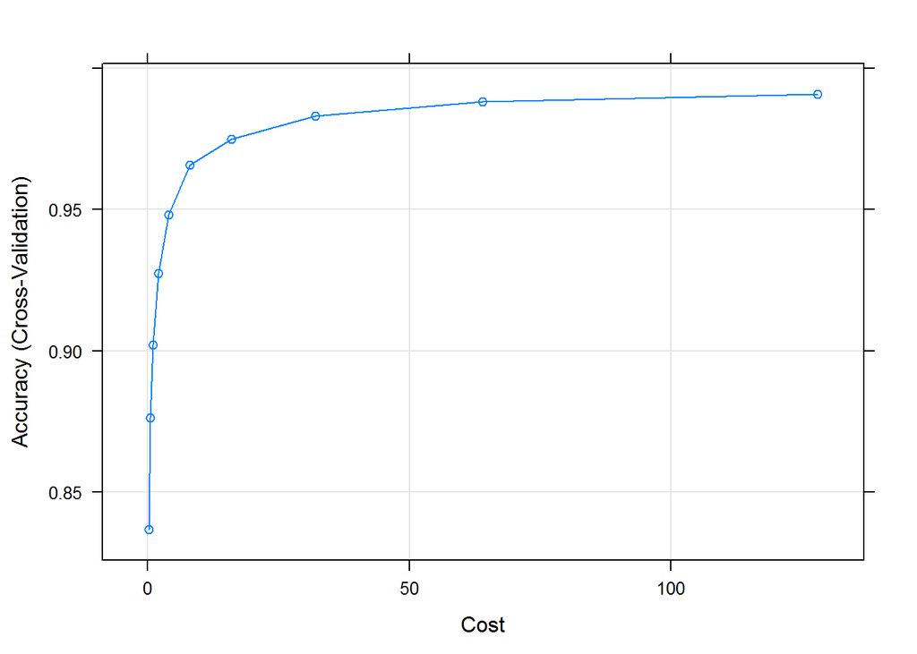

```r
load('classModel_svm.RData')
plot(classModel_svm)
```

The classification accuracy on the training set was:

```r
p<-predict(classModel_svm, preProcessedData)
confusionMatrix(p, data[, 42])
```

```
## Confusion Matrix and Statistics
##
##           Reference
## Prediction    A    B    C    D    E
##          A 5576   10    0    0    0
##          B    4 3785    1    0    0
##          C    0    2 3409   36    1
##          D    0    0   12 3174    0
##          E    0    0    0    6 3606
##
## Overall Statistics
##
##                Accuracy : 0.9963
##                  95% CI : (0.9954, 0.9971)
##     No Information Rate : 0.2844
##     P-Value [Acc > NIR] : < 2.2e-16
##
##                   Kappa : 0.9954
##  Mcnemar's Test P-Value : NA
##
## Statistics by Class:
##
##                      Class: A Class: B Class: C Class: D Class: E
## Sensitivity            0.9993   0.9968   0.9962   0.9869   0.9997
## Specificity            0.9993   0.9997   0.9976   0.9993   0.9996
## Pos Pred Value         0.9982   0.9987   0.9887   0.9962   0.9983
## Neg Pred Value         0.9997   0.9992   0.9992   0.9974   0.9999
## Prevalence             0.2844   0.1935   0.1744   0.1639   0.1838
## Detection Rate         0.2842   0.1929   0.1737   0.1618   0.1838
## Detection Prevalence   0.2847   0.1932   0.1757   0.1624   0.1841
## Balanced Accuracy      0.9993   0.9983   0.9969   0.9931   0.9997
```

2. Random forests We trained random forest implementation using caret’s train method and we tested 10 different parameters. Input data were not centered or scaled.

```r
#classModel_RF <-train(x=data[, -42], y=data[, 42], method="rf", trControl = trainControl(method = "cv", number=4, allowParallel = TRUE),  tuneLength=10)
```

The resulting model accuracy with respect to the parameters is

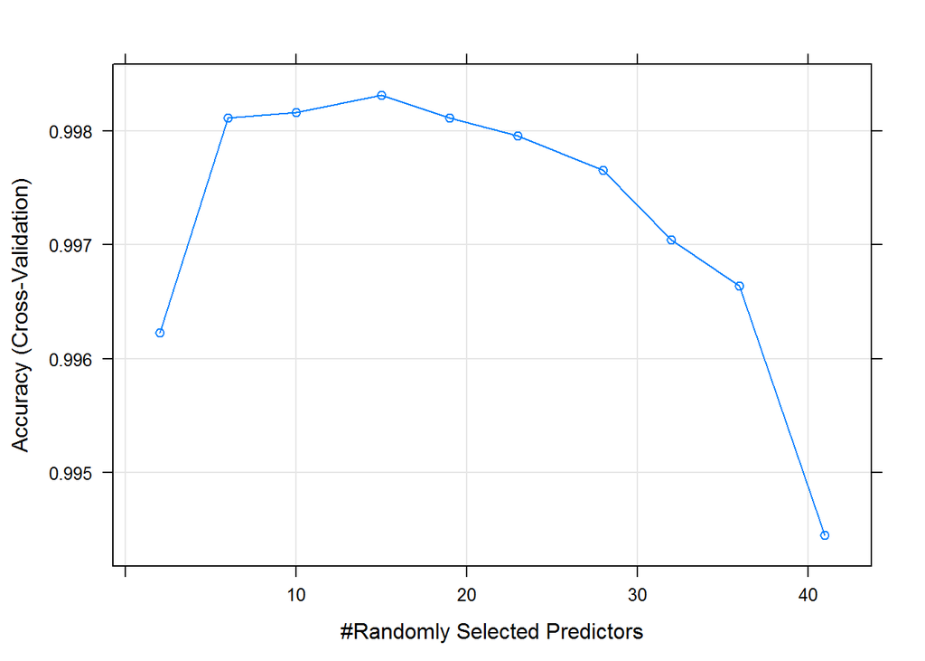

```r
load('classModel_RF_1.RData')
plot(classModel_RF)
```

Accuracy was used to select the optimal model using the largest value. The final value used for the model was mtry = 15. The classification accuracy on the training set was:

```r
p<-predict(classModel_RF, data[, -42])
confusionMatrix(p, data[, 42])
```

```
## Confusion Matrix and Statistics
##
##           Reference
## Prediction    A    B    C    D    E
##          A 5580    0    0    0    0
##          B    0 3797    0    0    0
##          C    0    0 3422    0    0
##          D    0    0    0 3216    0
##          E    0    0    0    0 3607
##
## Overall Statistics
##
##                Accuracy : 1
##                  95% CI : (0.9998, 1)
##     No Information Rate : 0.2844
##     P-Value [Acc > NIR] : < 2.2e-16
##
##                   Kappa : 1
##  Mcnemar's Test P-Value : NA
##
## Statistics by Class:
##
##                      Class: A Class: B Class: C Class: D Class: E
## Sensitivity            1.0000   1.0000   1.0000   1.0000   1.0000
## Specificity            1.0000   1.0000   1.0000   1.0000   1.0000
## Pos Pred Value         1.0000   1.0000   1.0000   1.0000   1.0000
## Neg Pred Value         1.0000   1.0000   1.0000   1.0000   1.0000
## Prevalence             0.2844   0.1935   0.1744   0.1639   0.1838
## Detection Rate         0.2844   0.1935   0.1744   0.1639   0.1838
## Detection Prevalence   0.2844   0.1935   0.1744   0.1639   0.1838
## Balanced Accuracy      1.0000   1.0000   1.0000   1.0000   1.0000
```